# 30th April

Anna Hutchinson

### Genomic control

It is important that we use genomic control (or something similar) to ensure that the P values are uniformly distributed under the null so that $P(P<p)=p$. If $P(P<p)>p$ then we may see inflation of V values. Although note that genomic control is a brute force tool and is not necessarily appropriate for targetted chips, such as the ImmunoChip.

I am unsure whether the P values have already been genomic-controlled. I derive the $\lambda$ value using various combinations of SNPs:

|  | lamdbda | lambda_1000 |
| --- | --- | --- |
| Use all SNPs | 1.6 | 1.07 |
| Use null reading SNPs | 0.93 | 0.99 |
| Use SNPs in non-dense regions | 1.3 | 1.03 |

The only mention of genomic control in the manuscript is (although note here they use 135,870 SNPs that passed QC whereas my dataset only has 124,000 SNPs):

*“We observed inflation of test statistics across all SNPs that passed quality control ($\lambda_{1,000} = 1.09$), which was expected as the Immunochip was designed to target robustly defined immune-mediated disease susceptibility loci. Excluding SNPs from regions reported here, $\lambda_{1,000}$ was reduced to 1.07; excluding all densely genotyped regions reduced $\lambda_{1,000}$ to 1.03”*

My values are comparable with theirs and I decide not to perform genomic-control on my P values.

### cFDR

I am working on new cFDR code that automatically incorporates the adjusment step.

$$\begin{equation}
\begin{split}
cFDR(p,q) &= P(H_0^p|P\leq p, Q\leq q)\\[2ex]
&= \dfrac{P(P\leq p|H_0^p, Q\leq q) P(H_0^p|Q\leq q)}{P(P\leq p |Q\leq q)}\\[2ex]
&= \dfrac{P(P\leq p|H_0^p)}{\dfrac{P(P\leq p, Q\leq q)}{P(Q\leq q)}} P(H_0^p|Q\leq q)\\[2ex]
&= \dfrac{p P(Q\leq q)}{P(P\leq p, Q\leq q)} \times \dfrac{P(Q\leq q|H_0^p)P(H_0^p)}{P(Q\leq q)}\\[2ex]
&\geq \dfrac{p}{P(P\leq p, Q\leq q)} \times P(Q\leq q|H_0^p)
\end{split}
\end{equation}$$

```r
pq_full <- readRDS("realdata.RDS")

p <- pq_full$p
q <- pq_full$q

# ensure smaller q are enriched for smaller p
if(cor(p,q,method="spearman") < 0) q <- -q

chr1 = which(pq_full$chr == 1)

# problems for very small p values (inflation)
# and very big p values (de-inflation) so pick out these
candidate_indices = c(which(pq_full$p<0.0005 | pq_full$p>0.99), sample(1:nrow(pq_full), 1000))

indices = intersect(chr1, candidate_indices)
fold = chr1 # leave out these indices
mode = 2 # leave one-chromosome-out
adj = TRUE # new method does adjustment separately - will look at including later
nt = 5000 # resolution of L curves (p)
nv = 1000 # resolution of L curves (q)
res_p = 500 # resolution for KDE estimates
res_q = 200
gx = min(p[indices])
zp = -qnorm(p/2)
maxx = max(zp)
maxy = max(q)
miny = min(q)

if (mode==2) sub = setdiff(1:length(zp), fold) else sub = 1:length(zp)

# define limits of q by adding 10% either side
q_10 <- (max(q[sub]) - min(q[sub])) * 0.1

# define upper limit of zp by adding 10%
zp_10 <- (max(zp[sub]) - min(zp[sub])) * 0.1

lims <- c(0, maxx + zp_10, miny-q_10, maxy+q_10) # c(xl, xu, yl, yu)

# folded normal KDE
kpq <- kde2d(c(zp[sub], -zp[sub]), c(q[sub], q[sub]), n=c(res_p, res_q), lims = lims) #h  = c(bandwidth.nrd(c(zp[sub], -zp[sub])), bandwidth.nrd(c(q[sub], q[sub]))))

qs  = q[sub][which(p[sub]>0.5)]
kq = density(c(qs, qs), from=lims[3], to=lims[4], n=res_q) #bw = bandwidth.nrd(c(qs, qs)))
```

I will look more into this at a later date but note that `kde2d` and `density` have different default bandwidths.

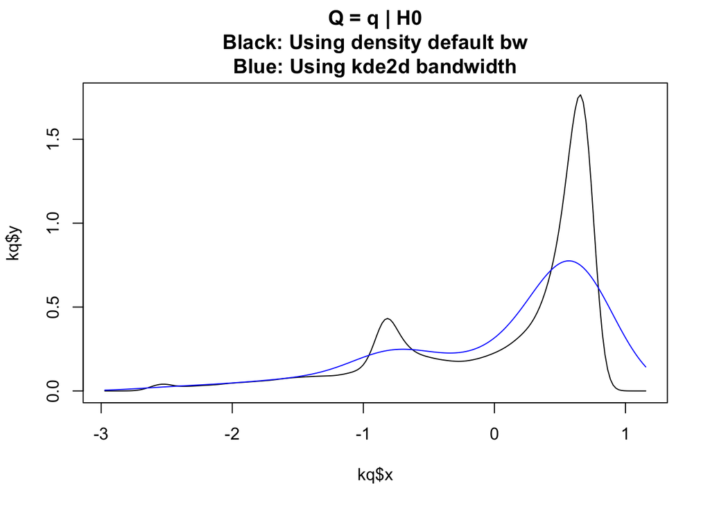

I ensure that the univariate PDF ($P(Q=q|H0)$) integrates to 1:

```r
integrate(approxfun(kq$x, kq$y), lims[3], lims[4])
```

```
## 1.00096 with absolute error < 5.5e-05
```

```r
kq$y <- kq$y/integrate(approxfun(kq$x, kq$y), lims[3], lims[4])$value
```

I then make the bivariate PDF ($P(P=p, Q=q)$) integrate to 1 (I think this is the right thing to do?)

```r
cell_size <- (diff(range(lims[1], lims[2])) / res_p) * (diff(range(lims[3], lims[4])) / res_q)
integ <- sum(kpq$z) * cell_size
integ
```

```
## [1] 0.5071539
```

```r
kpq$z <- kpq$z/integ
```

I compare on a single plot the univariate PDF, $P(Q=q|H0)$, and the bivariate PDF for a fixed P at $P=1$:

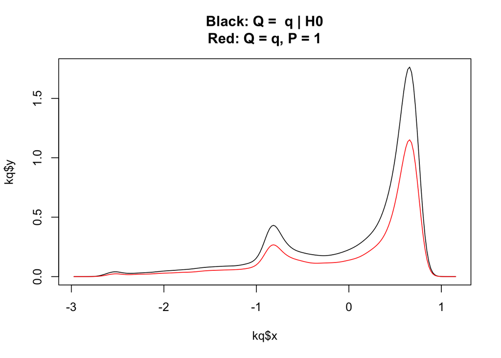

I then find the cdfs by summing across rows/columns [Note - should $P(P\leq1, Q\leq lims[4])=1$ and $P(Q\leq q|H0)=1$? In which case another standardisation method could be to ensure the top right entry of the cdf matrix is 1].

```r
##### sum to get P(Q <= q | h0)
kqh0 <- t(outer(kq$y, rep(1,res_p)))
int_kqh0 <- t(apply(kqh0, 1, cumsum))

##### sum to get P(P <= p, Q <= q)
int_kpq <- t(apply(apply(kpq$z[res_p:1,], 2, cumsum), 1, cumsum))[res_p:1, ]
```

But now we have an even bigger problem of scale differences….

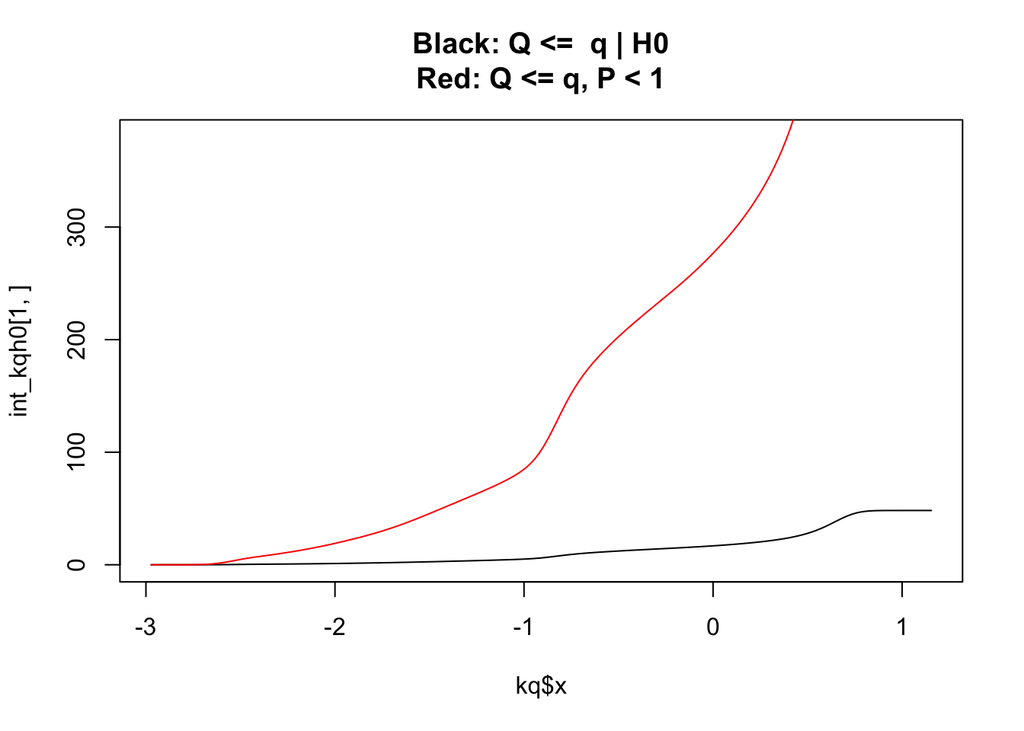

I use a sneaky normalisation trick and define `kgrid`($=P(P\leq p, Q\leq q)/P(Q\leq q|H0)$.

```r
int_kqh0 <- int_kqh0 * (max(int_kpq)/max(int_kqh0))

int_kpq[which(int_kpq==0)] = min(int_kpq[which(int_kpq>0)]) # avoid dividing by 0
int_kqh0[which(int_kqh0==0)] = min(int_kqh0[which(int_kqh0>0)]) # avoid dividing by 0

kgrid <- kpq
kgrid$z <- int_kpq/int_kqh0
```

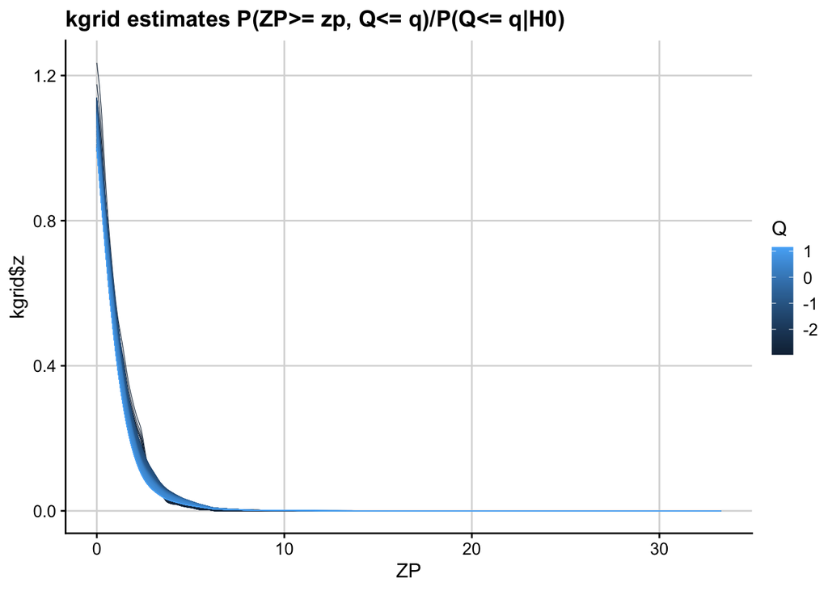

I then use this to define our adjusted cfdr estimator, ensuring it is strictly decreasing:

```r
# int_p is P(P\leq p)
int_p = outer(2*pnorm(-kpq$x), rep(1,res_q))

cgrid = kgrid
cgrid$z = int_p/kgrid$z
cgrid$z = apply(cgrid$z, 2, cummin) # make non-increasing
cgrid$z = apply(cgrid$z, 2, function(y) y-gx*cgrid$x+gx*maxx) # make strictly decreasing
```

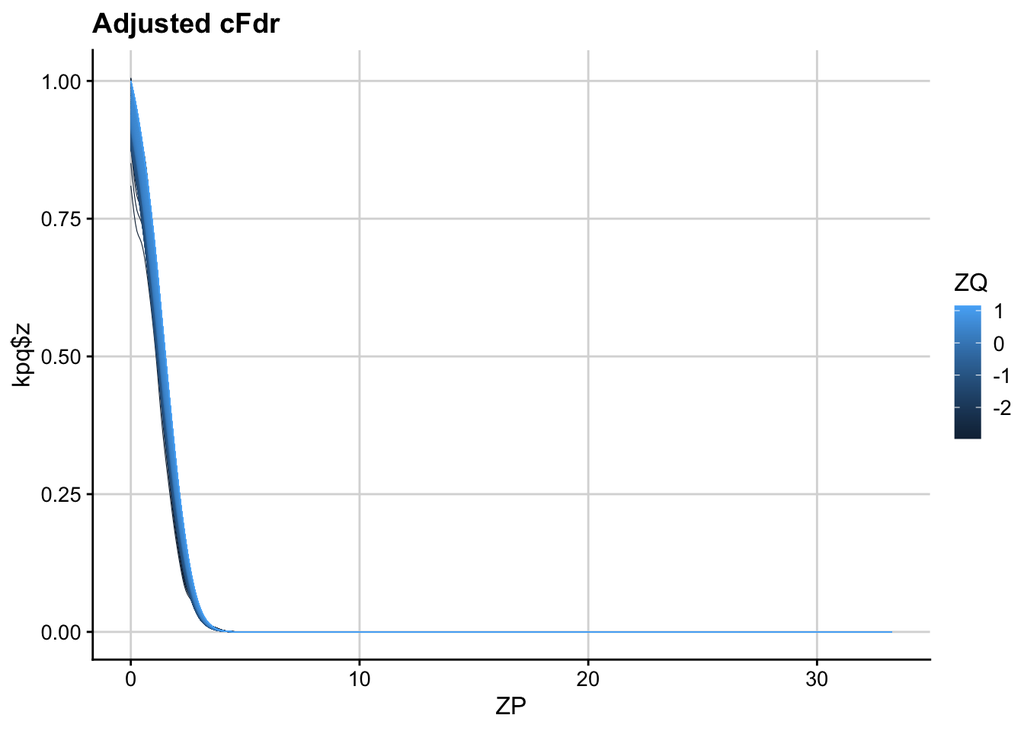

I then proceed as normal to find the L curves.

```r
if (!is.null(indices)) ccut = interp.surface(cgrid, cbind(pmin(zp[indices], maxx), pmin(q[indices], maxy)))

max(ccut)
```

```
## [1] 0.994664
```

```r
# define support of L curves
yval2 = seq(lims[3], lims[4], length.out=nv)
xval2 = outer(rep(1,length(ccut)), yval2)
xtest = seq(0, lims[2], length.out=nt)
ptest = 2*pnorm(-xtest)

for (i in 1:length(yval2)) {
  xdenom = interp.surface(kgrid, cbind(xtest, rep(yval2[i], length(xtest))))
  cfx = cummin(ptest/xdenom)
  xval2[,i] = approx(cfx-gx*xtest  + gx*maxx, xtest, ccut, rule=2, method="const", f=1)$y
}
```

Note that something is going wrong for large P values…

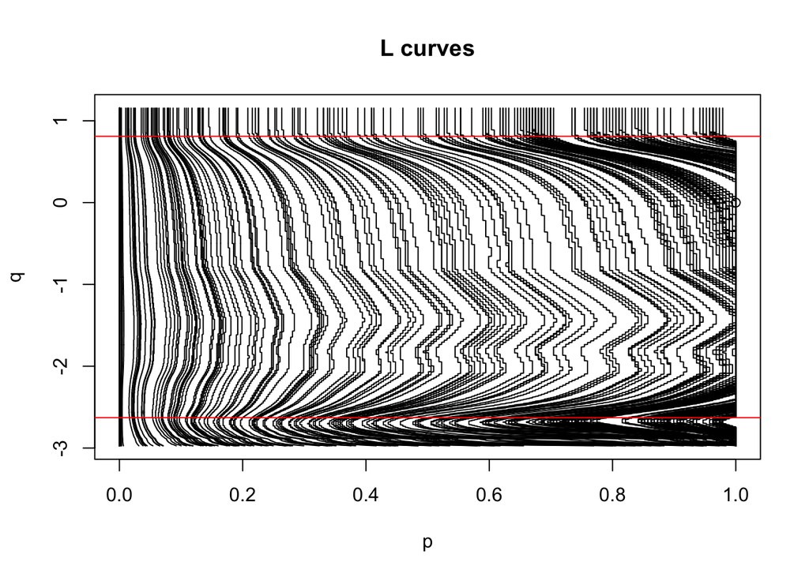

I then do the final integration step to obtain the final v values.

```r
# P | H0
fph0 = function(x) dunif(x)

# Q|H0
qs  = q[sub][which(p[sub]>0.5)]
kq = density(c(qs, qs), from=lims[3], to=lims[4], n=res_q) # define on same support as L curves

fqh0 <- approxfun(kq$x, kq$y)

fpqh0 <- function(s){
  fph0(s[,1])*fqh0(s[,2])
}

fullint <- polyCub(owin(poly=list(x = c(1, 0, 0, 1), y = c(lims[4], lims[4], lims[3], lims[3])), check = FALSE, fix = FALSE), fpqh0)

fullint
```

```
## [1] 1.006436
```

```r
# divide by this so that the density integrates to 1
fpqh0 <- function(s){
  (fph0(s[,1])*fqh0(s[,2]))/fullint
}

v <- apply(L$x, 1, function(x) {
  return(tryCatch(polyCub(owin(poly=list(x = c(x[nv], 0,0, x), y = c(L$y[nv], max(L$y), min(L$y), L$y)), check = FALSE, fix  = FALSE), fpqh0), error = function(e) NA))
}) %>% unlist()
```

The results are now similar to those when using the original code that did a seperate adjustment step using ecdfs. But this all still needs a bit of work to deal with very large and very small P values.

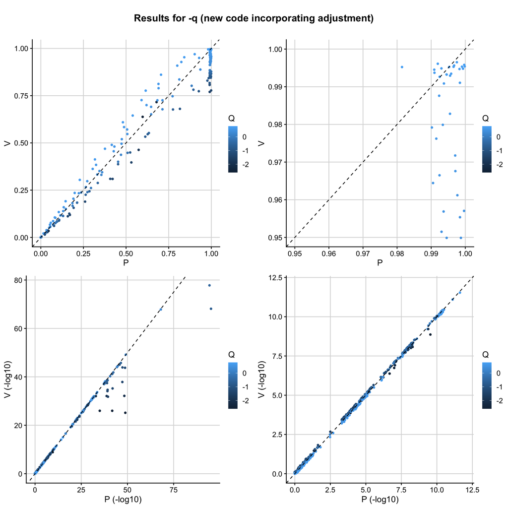

### Comparing with previous method (adjustment using ecdfs)

Note that in the previous method, `kgrid` approximated $P(P\leq p, Q\leq q)/P(Q\leq q)$ (easy as $P(Q\leq q)$ is taken from the first row of the matrix, i.e. for $P(Q\leq q, P<1)$) whereas in my new method `kgrid` approximates $P(P\leq p, Q\leq q)/P(Q\leq q|H0)$, which is harder.

The L curves using the previous code (seperate adjustment using ecdfs) are very different:

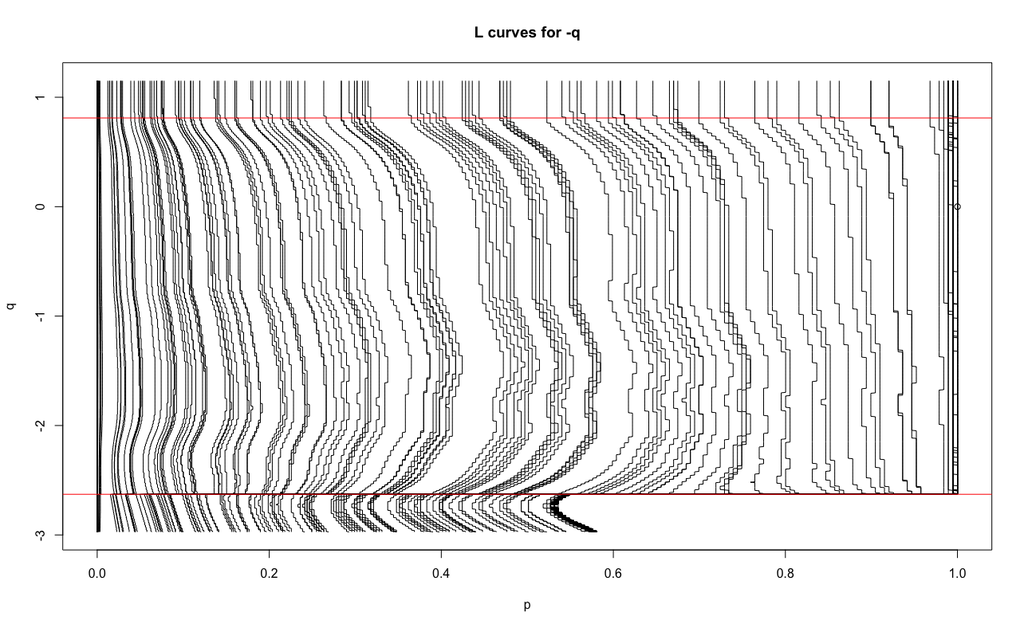

but the v values are comparable:

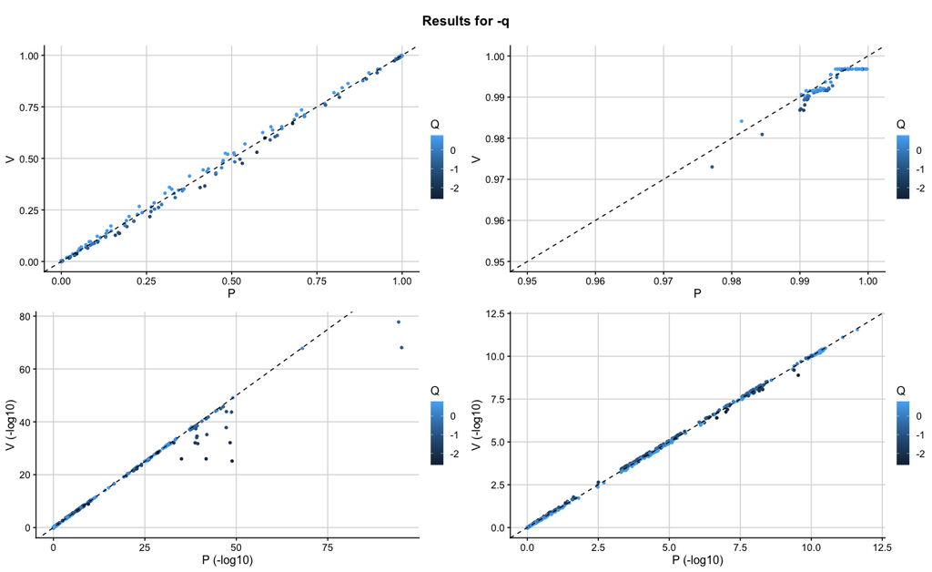

### Comments and queries

- I am using P values from `ic_t1d_onengut_allresults.csv.gz` (124726 SNPs) for my analysis. I have noticed there is another similar file in the directory: `hg19_gwas_ic_t1d_onengut_cc_4_19_1.tab.gz` (123130 SNPs). The p-values are very similar (not identical) - but I wonder what the difference is?
- In the adjustment using ecdf code `yval2 = seq(lims[3], lims[4], length.out=nv+1)[1:nv]` which means the L curves do not quite have `lims[4]` as the upper limit. This is because ecdfs are used for the adjustment and this will affect the integration step.
- I need to check why the `gx` trick isn’t working for very small q.
- I need to look at defining the bandwidths in the kde.